# Machine Learning I - Regression - Presentation

- Mateusz Domaradzki&Karol Ziolo

[figure not shown]

# Regression

## Data Preparation

### Weather

We decided to use only weather_general, without detailed verson of it. Thus, we merged some of the levels

```r
data$weather_general <- as.factor(data$weather_general)

data$weather_general[data$weather_general == "Maze"] <- "Fog"
data$weather_general[data$weather_general == "Haze"] <- "Smoke"
data$weather_general[data$weather_general == "Squall"] <- "Thunderstorm"
```

| Variable | Frequency |
| --- | --- |
| Clear | 8020 |
| Clouds | 10163 |
| Drizzle | 919 |
| Fog | 481 |
| Mist | 3491 |
| Rain | 3558 |
| Smoke | 760 |
| Snow | 1794 |
| Thunderstorm | 501 |

### Our transformations

Using barplots we noticed that the hour is highly correlated with the level of traffic

```r
time_of_the_day<-function(x) {
  result<-list()
  if(x>=6 & x<=8){
    result<-"Traffic_morning_peak_hour"
  }
  else if(x>8 & x<15){
    result<-"Working_hours"}
  else if(x>=15 & x<=17){
    result<-"Traffic_evening_peak_hour"}
  else{
    result <-"night"}
  return(result)
}
```

Also the season matters in interactions

```r
season_of_the_year <- function(x) {
  result<-list()
  if(x=='11' || x=='12' || x=='01'){
    result<-"Winter"
  }
  else if(x=='07' || x=='08' || x=='09' ){
    result<-"Summer_Holidays"}
  else{
    result <-"The_Rest_of_the_season"}
  return(result)
}
```

The day of the week is also an important factor

```r
day_of_the_wk<- function(x) {
  result<-list()
  if(x=='sobota' || x=='niedziela'){
    result<-"Weekend"
  }
  else{
    result <-"Working_day"}
  return(result)
}
```

### Final data

Our final data looks like that

- We decided to drop cloud_coverage due to 0 correlation with traffic.
- Rain_mm and snow_mm occur so rarely that we won’t use them, as we have weather_general which suggest the weather conditions.
- We dropped some outliers

| traffic | weather_general | temperature | season | day2 | hour2 |
| --- | --- | --- | --- | --- | --- |
| 508 | Clear | 11.5 | The_Rest_of_the_season | Working_day | night |
| 323 | Clear | 10.3 | The_Rest_of_the_season | Working_day | night |
| 274 | Clear | 8.0 | The_Rest_of_the_season | Working_day | night |
| 372 | Clear | 7.9 | The_Rest_of_the_season | Working_day | night |
| 812 | Clear | 6.4 | The_Rest_of_the_season | Working_day | night |
| 2720 | Clear | 5.5 | The_Rest_of_the_season | Working_day | night |
| 5674 | Clear | 5.1 | The_Rest_of_the_season | Working_day | Traffic_morning_peak_hour |
| 6512 | Clear | 5.0 | The_Rest_of_the_season | Working_day | Traffic_morning_peak_hour |
| 5473 | Clear | 9.3 | The_Rest_of_the_season | Working_day | Working_hours |
| 5096 | Clear | 18.8 | The_Rest_of_the_season | Working_day | Working_hours |
| 4887 | Clear | 20.1 | The_Rest_of_the_season | Working_day | Working_hours |
| 5335 | Clear | 21.2 | The_Rest_of_the_season | Working_day | Working_hours |
| 5699 | Clear | 22.0 | The_Rest_of_the_season | Working_day | Traffic_evening_peak_hour |
| 6130 | Clear | 22.0 | The_Rest_of_the_season | Working_day | Traffic_evening_peak_hour |
| 4620 | Clouds | 20.5 | The_Rest_of_the_season | Working_day | night |
| 3594 | Clouds | 17.5 | The_Rest_of_the_season | Working_day | night |
| 2895 | Clouds | 15.0 | The_Rest_of_the_season | Working_day | night |
| 2643 | Clear | 14.0 | The_Rest_of_the_season | Working_day | night |
| 1783 | Clear | 13.1 | The_Rest_of_the_season | Working_day | night |
| 1017 | Clear | 12.1 | The_Rest_of_the_season | Working_day | night |

## Best algorithm

### What we tried?

- OLS
- LASSO
- RIDGE
- Elastic approach between them
- KNN
- SVR

### The best algorithm - SVR

```r
ctrl_cv5 <- trainControl(method = "cv",
                         number = 5)

parametersC_sigma2 <-
  expand.grid(C = 415,
              sigma = 0.1)


svm_Radial2 <- train(traffic~. + weather_general*hour2  + day2*hour2 + weather_general*day2,
                            data = data_final,
                            method = "svmRadial",
                            tuneGrid = parametersC_sigma2,
                            trControl = ctrl_cv5)
```

### Plot real data/predicted data

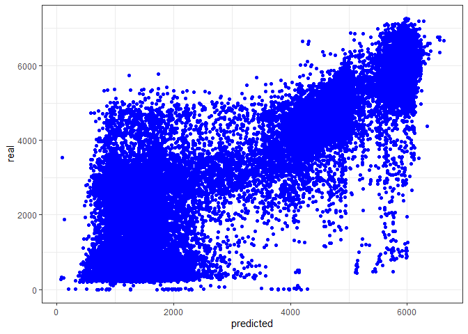

### EXPECTED MAPE

Im going to apply MAPE from a R package MLmetrics

```
## [1] 2.169793
```

# Classification

## Data Exploration

### General outlook on data

Let read the data.

### Age

We decided to merge groups “55-64” and “65+” into one group called “55+” to be more representative.

```r
data2$age[data2$age=="55-64"] <- "55+"
data2$age[data2$age == "65+"] <- "55+"

data2$age = factor(data2$age, levels = c("18-24",
                                         "25-34",
                                         "35-44",
                                         "45-54",
                                         "55+"),ordered = TRUE)

data2$age <- droplevels(data2$age)
```

### Education

The education variable is divided into many levels, which is not distributed evenly. We have many disproportions so we decided to merge people who left school at or before 18 into one group.

```r
data2$education[data2$education %in% c("Left school before 16 years",
                                       "Left school at 16 years",
                                       "Left school at 17 years",
                                       "Left school at 18 years")] <- "Left school at or before 18"

data2$education = factor(data2$education, levels = c("Left school at or before 18",
                                                     "Some college or university, no certificate or degree",
                                                     "Professional certificate/ diploma",
                                                     "University degree",
                                                     "Masters degree",
                                                     "Doctorate degree"),
                         ordered = TRUE)
data2$education <- droplevels(data2$education)
```

### Country

There is small number of people from Canada and Ireland so we decided to assign them to the group of others.

```r
data2$country[data2$country %in% c("Canada","Ireland")] <- "Other"
```

### Consumption

We decided to downgrade consumption variables into three groups: “regularly”, “occasionally” and “never”. We also dropped “Consumption Chocolate” and “Consumption Caffeine”.

```r
# Vector of consumption variables which concern us
consumption_variables = c("consumption_alcohol", "consumption_amphetamines",
                          "consumption_cannabis", "consumption_mushrooms",
                          "consumption_nicotine")
# Grouping function
fun =
  function(x){
  if (x %in% c("never used","used over a decade ago","used in last decade")){
    x = "never"}
  else if (x %in% c("used in last year","used in last month")){
    x = "occasionally"}
  else if (x %in% c("used in last week","used in last day")){
    x = "regularly"}
  }

# Applying grouping function
data2[consumption_variables] = unlist(lapply(data2[consumption_variables], function(y) lapply(y, fun)))

# Modifying into factors
data2[consumption_variables] = lapply(data2[consumption_variables],
                                     function(x) factor(x, levels = c("never","occasionally","regularly"),ordered = TRUE))

# Dropping "Consumption Chocolate" and "Consumption Caffeine" variables
data2 = data2[,-c(14,16)]
```

### Personality Variables

Checking for outliers.

```r
min_max = matrix(1:14,nrow = 7, ncol = 2)
colnames(min_max) = c("Minimum", "Maximum")
rownames(min_max) = names(which(sapply(data2,is.numeric)))
min_max[,1] = apply(data2[names(which(sapply(data2,is.numeric)))],2, min)
min_max[,2] = apply(data2[names(which(sapply(data2,is.numeric)))],2, max)
kable(min_max)
```

|  | Minimum | Maximum |
| --- | --- | --- |
| personality_neuroticism | 0 | 100 |
| personality_extraversion | 0 | 100 |
| personality_openness | 0 | 100 |
| personality_agreeableness | 0 | 100 |
| personality_conscientiousness | 0 | 100 |
| personality_impulsiveness | 0 | 100 |
| personality_sensation | 0 | 100 |

We decided to aggregate personality variables and create one called “personality”.

```r
data2["personality"] =
  colnames(data2[sapply(data2,is.numeric)])[apply(data2[sapply(data2,is.numeric)],1,which.max)]

data2$personality = as.factor(data2$personality)
```

### Dependent Variable

```r
kable(table(data2$consumption_cocaine_last_month))
```

| Var1 | Freq |
| --- | --- |
| No | 1373 |
| Yes | 127 |

```r
data2$consumption_cocaine_last_month = factor(data2$consumption_cocaine_last_month, levels = c("No","Yes"), ordered = TRUE)

data2 = data2[sapply(data2,is.factor)]
```

### Statistical Tests

```r
chisqr = matrix(1:10,nrow = 10, ncol = 1)
colnames(chisqr) = c("p-value")
rownames(chisqr) = names(which(sapply(data2,is.factor)))
chisqr[,1] = apply(data2[names(which(sapply(data2,is.factor)))],2,
                   function(x) round(chisq.test(x, data2$consumption_cocaine_last_month,correct=FALSE)$p.value,4))
kable(chisqr)
```

|  | p-value |
| --- | --- |
| age | 0.0000 |
| gender | 0.0003 |
| education | 0.0736 |
| consumption_alcohol | 0.0040 |
| consumption_amphetamines | 0.0000 |
| consumption_cannabis | 0.0000 |
| consumption_mushrooms | 0.0000 |
| consumption_nicotine | 0.0000 |
| consumption_cocaine_last_month | 0.0000 |
| personality | 0.0000 |

```r
data2 = data2[,-3]
data2$education
```

## Best algorithm

### What we tried?

- Logistic
- KNN
- SVM
- Random Forest

### The best algorithm - RF

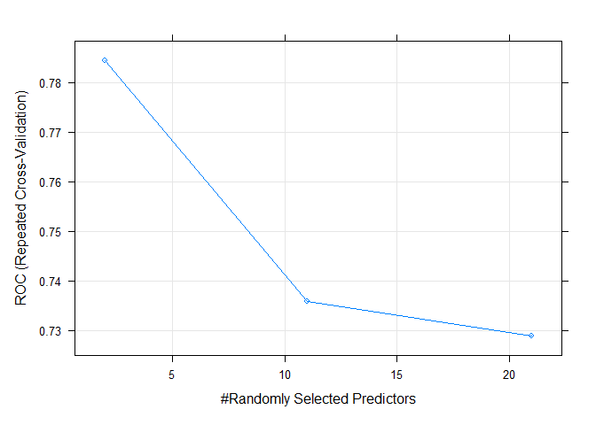

```r
options(contrasts = c("contr.treatment",  # for non-ordinal factors
                      "contr.treatment")) # for ordinal factors
set.seed(9432398) # We specify random seed

# Train control with cross-validation
ctrl_cv5 <- trainControl(method = "repeatedcv",
                         number = 5,
                         classProbs = TRUE,
                         summaryFunction = twoClassSummary,
                         repeats = 3)

ctrl_cv5$sampling = "up"

data2_rf_train <-
  train(consumption_cocaine_last_month ~ .,
        data2,
        method = "rf",
        metric = "ROC",
        trControl = ctrl_cv5)

plot(data2_rf_train)
```

### Balanced Accuracy

```r
rf_fitted = predict(data2_rf_train, data2)
rf_results = summary_binary_class(predicted_classes = rf_fitted,
                     real = data2$consumption_cocaine_last_month)
balanced_accuracy=confusionMatrix(as.factor(rf_fitted), data2$consumption_cocaine_last_month)$byClass[11]
kable(balanced_accuracy)
```

|  | x |
| --- | --- |
| Balanced Accuracy | 0.8411835 |